# xwMOOC 모형

만성 신부전증(Kidney) 예측 - LIME

2018-08-06

# 1 LIME을 통한 기계학습 모형 시각화[^1]

UCI 기계학습 저장소(Machine Learning Repository)에서 [Chronic_Kidney_Disease Data Set](http://archive.ics.uci.edu/ml/datasets/Chronic_Kidney_Disease)을 다운로드 받아 블랙박스 기계학습 모형을 LIME 방법론으로 시각화하는 방법을 살펴보자.

만성 신부전증 예측 데이터는 그 자체로 청소가 잘 되어 있어 `janitor`를 사용하는 데이터 정제과정이 필요하지 않지만, 결측값이 거의 모든 변수에 들어 있어 결측값 자동화에 대한 처리와 함께 `Random Forest` 모형에 넣을 수 있도록 범주형 변수에 대한 가변수처리(One-hot)와 연속형 변수에 대한 표준화 작업이 필요하다.

기계학습 모형이 나오게 되면 `LIME`을 사용해서 오분류된 관측점을 파악하고 변수 8개를 통원해서 어떤 변수가 오분류에 가장 큰 역할을 했는지 시각적으로 살펴본다.

[figure not shown]

# 2 결측데이터 [^2]

가장 먼저 불러온 데이터에 결측점에 대한 현상 파악이 우선되어야 한다. 이를 위해서 `VIM` 팩키지 `aggr()` 함수를 사용해서 결측점이 많이 분포된 변수와 변수들간의 관계에 대해서 시각적으로 이해한다. 어떤 변수에 어떤 관측점에 결측데이터가 위치해 있는지 파악해 두는 것은 다음 단계에서 결측값을 채워넣는데 도움이 된다.

`missForest` 팩키지 `missForest()` 함수를 사용해서 결측값을 채워넣고 정도도 확인해 둔다. 결측값을 채워넣는 팩키지는 5가지가 존재하는데 각 팩키지마다 용도를 확인하고 적절하게 사용한다. 실무에서 추천하는 것은 `Hmsic`와 `missForest`로 연속형 범주형 변수 유형에 구애받지 않고 적은 코드량으로 양질의 결측값을 채워넣을 수 있다.

- `MICE`
- `Amelia`
- `missForest`
- `Hmisc`
- `mi`

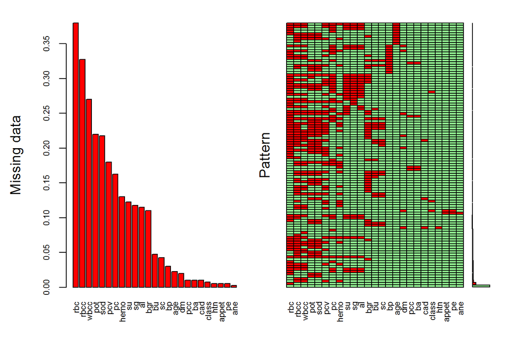

```
 Variables sorted by number of missings:
 Variable  Count
      rbc 0.3800
     rbcc 0.3275
     wbcc 0.2700
      pot 0.2200
      sod 0.2175
      pcv 0.1800
       pc 0.1625
     hemo 0.1300
       su 0.1225
       sg 0.1175
       al 0.1150
      bgr 0.1100
       bu 0.0475
       sc 0.0425
       bp 0.0300
      age 0.0225
       dm 0.0200
      pcc 0.0100
       ba 0.0100
      cad 0.0100
    class 0.0075
      htn 0.0050
    appet 0.0050
       pe 0.0050
      ane 0.0025
```

```r
# 0. 환경설정 -----
library(tidyverse)
library(janitor)
library(farff)
library(missForest)
library(caret)
library(lime)
library(skimr)

# 1. 데이터 가져오기 -----

data_file <- file.path("data/chronic_kidney_disease_full.arff")

data <- readARFF(data_file)

# 2. 결측 데이터 -----
#
## 2.1. 결측 데이터 확인 -----
# map(data, is.na) %>%
#     map_df(., sum) %>%
#     gather(variable, miss_num) %>%
#     arrange(desc(miss_num))

## 2.2. 결측 현황 시각화 -----
missing_plot <- VIM::aggr(data, col=c('lightgreen','red'),
                  numbers=FALSE, sortVars=TRUE,
                  labels=names(data), cex.axis=.7,
                  combined = FALSE,
                  gap=3, ylab=c("Missing data","Pattern"))
```

```r
## 2.3. 결측 현황 데이터 -----
missing_plot$missings %>% tbl_df %>%
    clean_names() %>%
    arrange(desc(count))
```

```
# A tibble: 25 x 2
   variable count
   <chr>    <int>
 1 rbc        152
 2 rbcc       131
 3 wbcc       108
 4 pot         88
 5 sod         87
 6 pcv         72
 7 pc          65
 8 hemo        52
 9 su          49
10 sg          47
# ... with 15 more rows
```

```r
# 3. 결측 채워넣기 -----
data_imp_df <- missForest(data, ntree = 200, mtry=10)
```

```
  missForest iteration 1 in progress...done!
  missForest iteration 2 in progress...done!
  missForest iteration 3 in progress...done!
  missForest iteration 4 in progress...done!
  missForest iteration 5 in progress...done!
  missForest iteration 6 in progress...done!
```

```r
data_imp_df$OOBerror
```

```
    NRMSE       PFC
0.3633619 0.1946855
```

# 3 모형 데이터 생성 [^3]

`missForest()` 함수로 결측값을 채워넣은 객체를 뽑아내서 연속형인 경우 먼저 `scale()` 함수로 표준화를 하고, `caret` 팩키지 `dummyVars()` 함수로 범주형 변수를 가변수(One-Hot) 처리한 후 예측변수(`class`)와 결합하여 모형 데이터프레임을 생성한다.

```r
# 2. 모형데이터 -----
## 2.1. 연속형 변수 표준화 -----
data_imp_df <- data_imp_df$ximp %>%
    mutate_if(is.numeric, scale)

## 2.2. 가변수(dummy) 생성 -----
data_dummy <- dummyVars(class ~., data=data_imp_df)
data_dummy_df <- data.frame(predict(data_dummy, newdata = data_imp_df))

## 2.3. X, Y 병합 -----

data_df <- data_imp_df %>% select(class) %>%
    cbind(data_dummy_df) %>%
    tbl_df
```

# 4 Random Forest 예측모형

훈련데이터와 시험데이터로 나누고 `rf` 모형으로 최적 모형을 구축하고 나서, 모형의 성능을 시험데이터를 통해 파악한다.

```r
# 3. 모형 -----
set.seed(42)
index <- createDataPartition(data_df$class, p = 0.9, list = FALSE)
train_data <- data_df[index, ]
test_data  <- data_df[-index, ]

model_rf <- caret::train(class ~ .,
                         data = train_data,
                         method = "rf", # random forest
                         trControl = trainControl(method = "repeatedcv",
                                                  number = 10,
                                                  repeats = 5,
                                                  verboseIter = FALSE))

# 4. 모형성능과 예측 -----
pred_df <- data.frame(sample_id = 1:nrow(test_data),
                   predict(model_rf, test_data, type = "prob"),
                   actual = test_data$class) %>%
    tbl_df()

pred_df <- pred_df %>%
    mutate(prediction = colnames(.)[2:3][apply(.[, 2:3], 1, which.max)],
           correct = ifelse(actual == prediction, "correct", "wrong")) %>%
    mutate(prediction = factor(prediction))

confusionMatrix(pred_df$actual, pred_df$prediction)
```

```
Confusion Matrix and Statistics

          Reference
Prediction ckd notckd
    ckd     23      2
    notckd   0     15

               Accuracy : 0.95
                 95% CI : (0.8308, 0.9939)
    No Information Rate : 0.575
    P-Value [Acc > NIR] : 1.113e-07

                  Kappa : 0.8961
 Mcnemar's Test P-Value : 0.4795

            Sensitivity : 1.0000
            Specificity : 0.8824
         Pos Pred Value : 0.9200
         Neg Pred Value : 1.0000
             Prevalence : 0.5750
         Detection Rate : 0.5750
   Detection Prevalence : 0.6250
      Balanced Accuracy : 0.9412

       'Positive' Class : ckd
```

# 5 블랙박스모형 살펴보기

`LIME` 방법론을 적용하기 위해서 우선 훈련데이터와 시험데이터를 분리한다. 그리고 나서 `lime()`을 호출하여 lime 객체를 만들고 이를 `explain()` 함수에 넣어 블랙박스 모형내부를 들여다 본다.

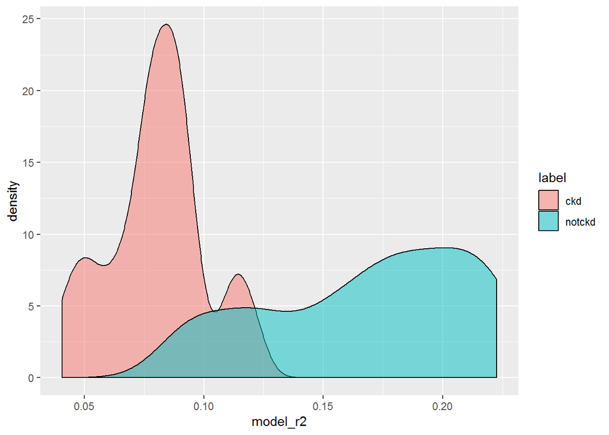

```r
# 5. 모형 설명(LIME) -----
## 5.1. 데이터셋 준비
train_x <- dplyr::select(train_data, -class)
test_x <- dplyr::select(test_data, -class)

train_y <- dplyr::select(train_data, class)
test_y <- dplyr::select(test_data, class)

## 5.2. 모형 설명자(Explainer)
explainer <- lime(train_x, model_rf, n_bins = 5, quantile_bins = TRUE)

explanation_df <- lime::explain(test_x, explainer,
                                n_labels = 1,
                                n_features = 8,
                                n_permutations = 1000,
                                feature_select = "highest_weights")

## 5.3. 모형 신뢰성(Model Reliability)
explanation_df %>%
    ggplot(aes(x = model_r2, fill = label)) +
    geom_density(alpha = 0.5)
```

시험데이터에서 오분류된 사례를 찾아내어 이를 `plot_features()` 함수에 넣어 어떤 변수가 오분류에 기여를 했는지 시각적으로 파악한다.

```r
## 5.4. 오분류 사례
pred_df %>%
    filter(correct=="wrong")
```

```
# A tibble: 2 x 6
  sample_id   ckd notckd actual prediction correct
      <int> <dbl>  <dbl> <fct>  <fct>      <chr>
1        13 0.468  0.532 ckd    notckd     wrong
2        22 0.446  0.554 ckd    notckd     wrong
```

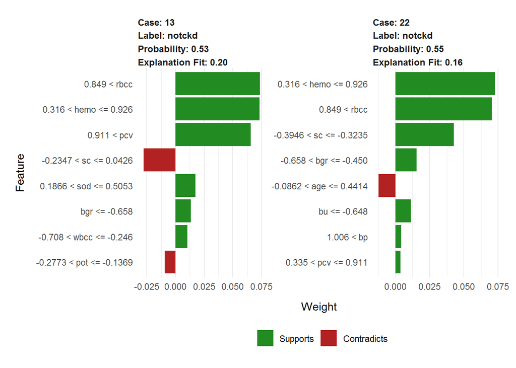

```r
plot_features(explanation_df[c(97:104, 169:176),], ncol = 2)
```

[^1]: [Shirin playgRound (2017-12-12), “Explaining Predictions of Machine Learning Models with LIME - Münster Data Science Meetup”](https://shirinsplayground.netlify.com/2017/12/lime_sketchnotes/)
[^2]: [ANALYTICS VIDHYA CONTENT TEAM, (MARCH 4, 2016), “Tutorial on 5 Powerful R Packages used for imputing missing values”](https://www.analyticsvidhya.com/blog/2016/03/tutorial-powerful-packages-imputing-missing-values/)
[^3]: [Rahul Sangole hacking my way through stats and ml, (September 27, 2017), Performance Benchmarking for Dummy Variable Creation](https://www.analyticsvidhya.com/blog/2016/03/tutorial-powerful-packages-imputing-missing-values/)